# R Notebook

```r
rm(list=ls())
library(ggplot2)
library(dplyr)
```

## Project - 2

Exploring the Data

```r
nei <- readRDS("data/summarySCC_PM25.rds")
scc <- readRDS("data/Source_Classification_Code.rds")
```

- fips: A five-digit number (represented as a string) indicating the U.S. county
- SCC: The name of the source as indicated by a digit string (see source code classification table)
- Pollutant: A string indicating the pollutant
- Emissions: Amount of PM2.5 emitted, in tons
- type: The type of source (point, non-point, on-road, or non-road)
- year: The year of emissions recorded

### Question 1

Have total emissions from PM2.5 decreased in the United States from 1999 to 2008? Using the base plotting system, make a plot showing the total PM2.5 emission from all sources for each of the years 1999, 2002, 2005, and 2008.

```r
str(nei)
```

```
'data.frame':   6497651 obs. of  6 variables:
 $ fips     : chr  "09001" "09001" "09001" "09001" ...
 $ SCC      : chr  "10100401" "10100404" "10100501" "10200401" ...
 $ Pollutant: chr  "PM25-PRI" "PM25-PRI" "PM25-PRI" "PM25-PRI" ...
 $ Emissions: num  15.714 234.178 0.128 2.036 0.388 ...
 $ type     : chr  "POINT" "POINT" "POINT" "POINT" ...
 $ year     : int  1999 1999 1999 1999 1999 1999 1999 1999 1999 1999 ...
```

```r
names(scc)
```

```
 [1] "SCC"                 "Data.Category"       "Short.Name"          "EI.Sector"
 [5] "Option.Group"        "Option.Set"          "SCC.Level.One"       "SCC.Level.Two"
 [9] "SCC.Level.Three"     "SCC.Level.Four"      "Map.To"              "Last.Inventory.Year"
[13] "Created_Date"        "Revised_Date"        "Usage.Notes"
```

```r
unique(nei$Pollutant)
```

```
[1] "PM25-PRI"
```

```r
table(nei$year)
```

```
   1999    2002    2005    2008
1108469 1698677 1713850 1976655
```

```r
summary(nei$Emissions)
```

```
    Min.  1st Qu.   Median     Mean  3rd Qu.     Max.
     0.0      0.0      0.0      3.4      0.1 646952.0
```

```r
nei_total <- aggregate(Emissions ~ year,  data = nei, FUN = sum )
nei_total
```

| year | Emissions |
| --- | --- |
| 1999 | 7332967 |
| 2002 | 5635780 |
| 2005 | 5454703 |
| 2008 | 3464206 |

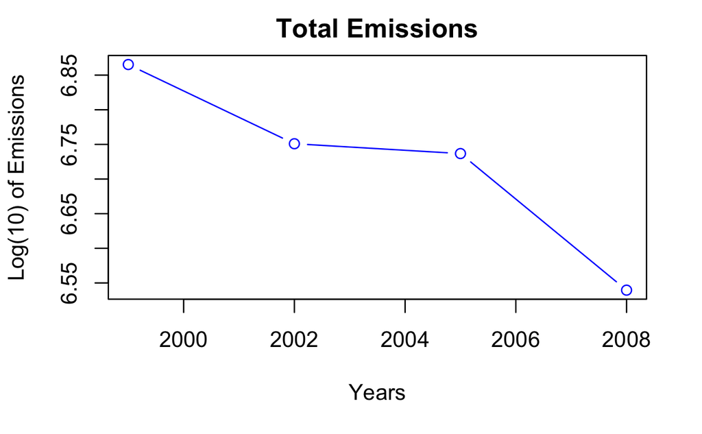

```r
with(nei_total,
     plot(y = log10(Emissions), x =year,
     xlab = "Years", ylab = "Log(10) of Emissions",
     main = "Total Emissions",
     type = "b", col = "blue",
     lty = 1, lwd =1))
```

```r
# Close the png file
# dev.off()
```

### Question 2

Have total emissions from PM2.5 decreased in the Baltimore City, Maryland (fips == “24510”) from 1999 to 2008? Use the base plotting system to make a plot answering this question.

[figure not shown]

```r
# take a subset of nei, Baltimore city
baltimore <- subset(nei, fips =="24510")
baltimore_total <- aggregate(Emissions ~ year,  data = baltimore, FUN = sum )

# Open a png file
#png(filename = "plot2.png",
#    width = 480,
#    height = 480)

with(nei_total,
     plot(y = log10(Emissions), x =year,
     xlab = "Years", ylab = "Log(10) of Emissions",
     main = "Total Emissions - Baltimore City",
     type = "b", col = "forestgreen",
     lty = 1, lwd =1))
```

```r
# Close the png file
#dev.off()
```

### Question 3

Of the four types of sources indicated by the type (point, nonpoint, onroad, nonroad) variable, which of these four sources have seen decreases in emissions from 1999–2008 for Baltimore City? Which have seen increases in emissions from 1999–2008? Use the ggplot2 plotting system to make a plot answer this question.

```r
tapply(baltimore$Emissions, baltimore$type, mean, na.rm=TRUE)
```

```
  NON-ROAD   NONPOINT    ON-ROAD      POINT
 2.5686158 45.7734670  0.6254108  5.7601914
```

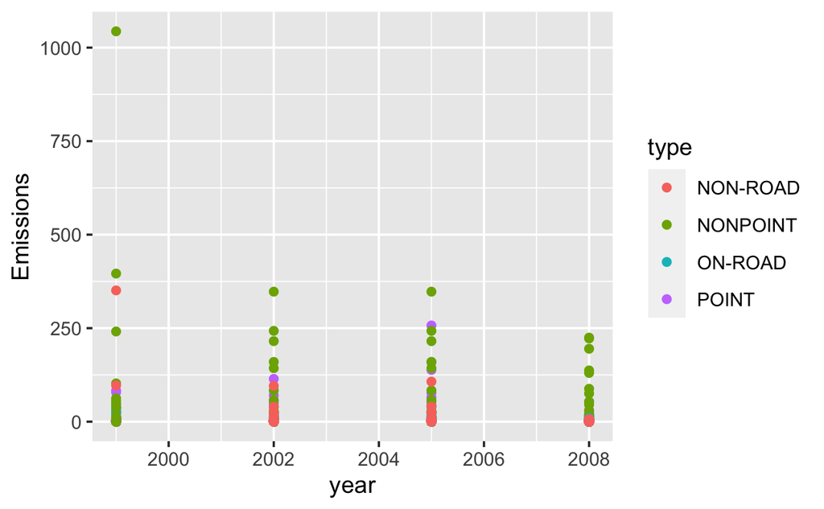

```r
library(ggplot2)
qplot(x = year, y = Emissions, data = baltimore, color = type)
```

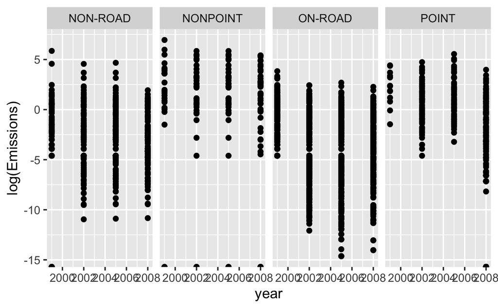

```r
qplot(x = year, y = log(Emissions), data = baltimore, facets = .~type)
```

```
Warning: Removed 128 rows containing non-finite values (stat_smooth).
```

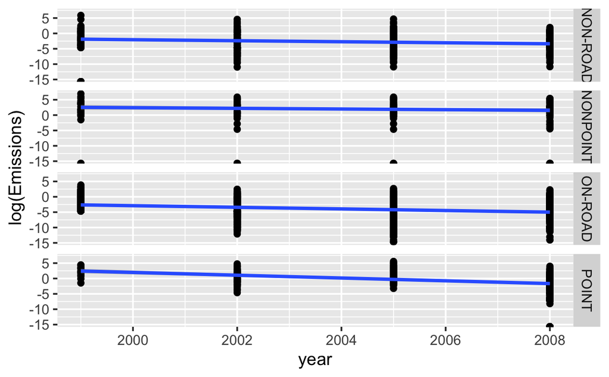

```r
qplot(x = year, y = log(Emissions), data = baltimore, facets = type ~ .) +
    geom_smooth(method = "lm")
```

```
Warning: Removed 128 rows containing non-finite values (stat_smooth).
```

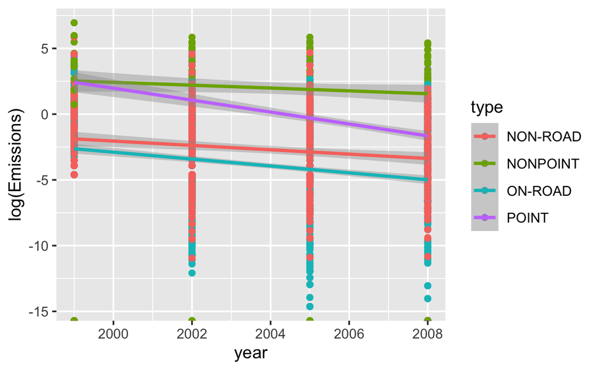

```r
qplot(x = year, y = log(Emissions), data = baltimore, color = type) +
    geom_smooth(method = "lm")
```

```r
baltimore_total2 <- aggregate(Emissions ~ year + type,  data = baltimore, FUN = sum )
baltimore_total2
```

| year | type | Emissions |
| --- | --- | --- |
| 1999 | NON-ROAD | 522.94000 |
| 2002 | NON-ROAD | 240.84692 |
| 2005 | NON-ROAD | 248.93369 |
| 2008 | NON-ROAD | 55.82356 |
| 1999 | NONPOINT | 2107.62500 |
| 2002 | NONPOINT | 1509.50000 |
| 2005 | NONPOINT | 1509.50000 |
| 2008 | NONPOINT | 1373.20731 |
| 1999 | ON-ROAD | 346.82000 |
| 2002 | ON-ROAD | 134.30882 |

[output cut: 6 more lines]

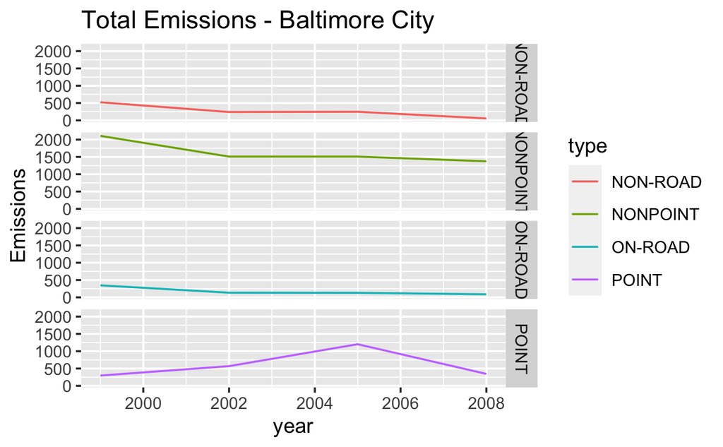

```r
# Open a png file
# png(filename = "plot3.png",
#    width = 480,
#    height = 480)

ggplot(baltimore_total2, aes(x = year, y = Emissions)) +
    geom_line(aes(color = type)) +
    facet_grid(vars(type)) +
    labs(title ="Total Emissions - Baltimore City")
```

```r
# Close the png file
# dev.off()
```

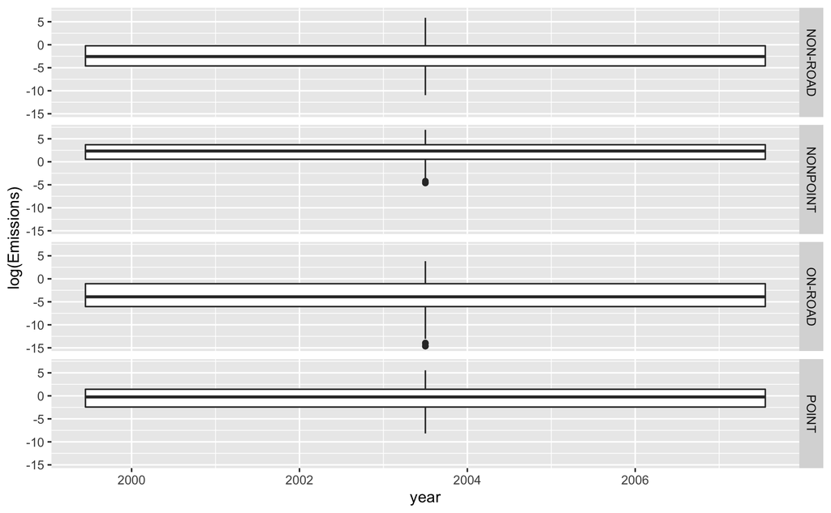

```r
ggplot(baltimore,aes(year, log(Emissions))) +
    geom_boxplot() + facet_grid(type ~ .)
```

### Question 4

Across the United States, how have emissions from coal combustion-related sources changed from 1999–2008?

```r
unique(scc$EI.Sector)
```

```
 [1] Fuel Comb - Electric Generation - Coal
 [2] Fuel Comb - Electric Generation - Oil
 [3] Fuel Comb - Electric Generation - Natural Gas
 [4] Fuel Comb - Electric Generation - Other
 [5] Fuel Comb - Electric Generation - Biomass
 [6] Fuel Comb - Industrial Boilers, ICEs - Coal
 [7] Fuel Comb - Industrial Boilers, ICEs - Oil
 [8] Fuel Comb - Industrial Boilers, ICEs - Natural Gas
 [9] Fuel Comb - Industrial Boilers, ICEs - Other
[10] Fuel Comb - Industrial Boilers, ICEs - Biomass
[11] Fuel Comb - Comm/Institutional - Coal
[12] Fuel Comb - Comm/Institutional - Oil
[13] Fuel Comb - Comm/Institutional - Natural Gas
[14] Fuel Comb - Comm/Institutional - Other
[15] Fuel Comb - Comm/Institutional - Biomass
```

[output cut: 45 more lines]

```r
coal <- grepl("[Cc]oal", scc$EI.Sector)
sum(coal)
```

```
[1] 99
```

```r
coal2 = grepl("[Cc]oal", scc$Short.Name) & grepl("[Cc]omb", scc$Short.Name)
sum(coal2)
```

```
[1] 91
```

```r
coal_scc <- scc$SCC[coal2]
nei_coal <- nei[nei$SCC %in% coal_scc, ]

nei_total4 <- aggregate(Emissions ~ year ,  data = nei_coal, FUN = sum )
nei_total4
```

| year | Emissions |
| --- | --- |
| 1999 | 575206.5 |
| 2002 | 547380.1 |
| 2005 | 553549.4 |
| 2008 | 343979.3 |

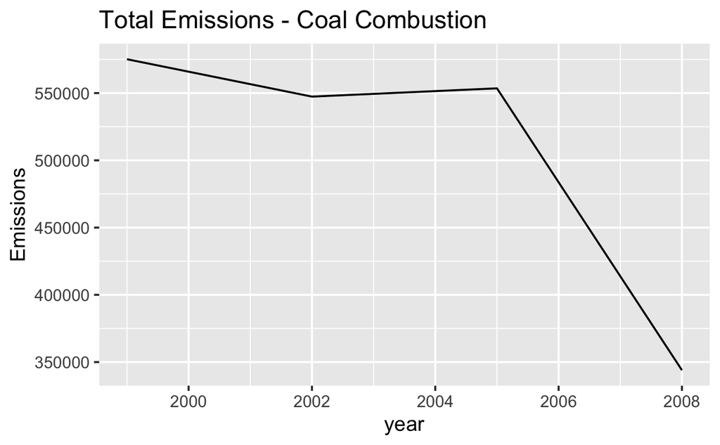

```r
# Open a png file
# png(filename = "plot4.png",
#    width = 480,
#    height = 480)

ggplot(nei_total4, aes(year, Emissions)) +
    geom_line()  +
    labs(title ="Total Emissions - Coal Combustion")
```

```r
# Close the png file
# dev.off()
```

### Questions 5

How have emissions from motor vehicle sources changed from 1999–2008 in Baltimore City?

```r
unique(scc$EI.Sector)
```

```
 [1] Fuel Comb - Electric Generation - Coal             Fuel Comb - Electric Generation - Oil
 [3] Fuel Comb - Electric Generation - Natural Gas      Fuel Comb - Electric Generation - Other
 [5] Fuel Comb - Electric Generation - Biomass          Fuel Comb - Industrial Boilers, ICEs - Coal
 [7] Fuel Comb - Industrial Boilers, ICEs - Oil         Fuel Comb - Industrial Boilers, ICEs - Natural Gas
 [9] Fuel Comb - Industrial Boilers, ICEs - Other       Fuel Comb - Industrial Boilers, ICEs - Biomass
[11] Fuel Comb - Comm/Institutional - Coal              Fuel Comb - Comm/Institutional - Oil
[13] Fuel Comb - Comm/Institutional - Natural Gas       Fuel Comb - Comm/Institutional - Other
[15] Fuel Comb - Comm/Institutional - Biomass           Industrial Processes - NEC
[17] Fuel Comb - Residential - Other                    Fuel Comb - Residential - Oil
[19] Fuel Comb - Residential - Natural Gas              Fuel Comb - Residential - Wood
[21] Mobile - On-Road Gasoline Light Duty Vehicles      Mobile - On-Road Gasoline Heavy Duty Vehicles
[23] Mobile - On-Road Diesel Light Duty Vehicles        Mobile - On-Road Diesel Heavy Duty Vehicles
[25] Mobile - Non-Road Equipment - Gasoline             Mobile - Non-Road Equipment - Other
[27] Mobile - Non-Road Equipment - Diesel               Mobile - Aircraft
[29] Mobile - Commercial Marine Vessels                 Mobile - Locomotives
```

[output cut: 16 more lines]

```r
motor = grepl("[vV]ehicle", scc$EI.Sector)

scc[motor, ]
```

|  | SCC | Data.Category | Short.Name | EI.Sector | Option.Group | Option.Set | SCC.Level.One | SCC.Level.Two | SCC.Level.Three | SCC.Level.Four | Map.To | Last.Inventory.Year | Created_Date | Revised_Date | Usage.Notes |
| --- | --- | --- | --- | --- | --- | --- | --- | --- | --- | --- | --- | --- | --- | --- | --- |
| 542 | 2201001000 | Onroad | Highway Veh - Gasoline - Light Duty Vehicles (LDGV) - Total: All Road Types | Mobile - On-Road Gasoline Light Duty Vehicles |  |  | Mobile Sources | Highway Vehicles - Gasoline | Light Duty Gasoline Vehicles (LDGV) | Total: All Road Types | NA | 2005 |  | 7/25/2008 0:00:00 |  |
| 543 | 2201001110 | Onroad | Highway Veh - Gasoline - Light Duty Vehicles (LDGV) - Rural Interstate: Total | Mobile - On-Road Gasoline Light Duty Vehicles |  |  | Mobile Sources | Highway Vehicles - Gasoline | Light Duty Gasoline Vehicles (LDGV) | Rural Interstate: Total | NA | NA |  |  |  |
| 544 | 2201001111 | Onroad | Highway Veh - Gasoline - Light Duty Vehicles (LDGV) - Interstate: Rural Time 1 | Mobile - On-Road Gasoline Light Duty Vehicles |  |  | Mobile Sources | Highway Vehicles - Gasoline | Light Duty Gasoline Vehicles (LDGV) | Interstate: Rural Time 1 | NA | 2002 |  |  |  |
| 545 | 2201001112 | Onroad | Highway Veh - Gasoline - Light Duty Vehicles (LDGV) - Interstate: Rural Time 2 | Mobile - On-Road Gasoline Light Duty Vehicles |  |  | Mobile Sources | Highway Vehicles - Gasoline | Light Duty Gasoline Vehicles (LDGV) | Interstate: Rural Time 2 | NA | 2002 |  |  |  |
| 546 | 2201001113 | Onroad | Highway Veh - Gasoline - Light Duty Vehicles (LDGV) - Interstate: Rural Time 3 | Mobile - On-Road Gasoline Light Duty Vehicles |  |  | Mobile Sources | Highway Vehicles - Gasoline | Light Duty Gasoline Vehicles (LDGV) | Interstate: Rural Time 3 | NA | 2002 |  |  |  |
| 547 | 2201001114 | Onroad | Highway Veh - Gasoline - Light Duty Vehicles (LDGV) - Interstate: Rural Time 4 | Mobile - On-Road Gasoline Light Duty Vehicles |  |  | Mobile Sources | Highway Vehicles - Gasoline | Light Duty Gasoline Vehicles (LDGV) | Interstate: Rural Time 4 | NA | 2002 |  |  |  |
| 548 | 220100111B | Onroad | Highway Veh - Gasoline - Light Duty Vehicles (LDGV) - Rural Interstate: Brake Wear | Mobile - On-Road Gasoline Light Duty Vehicles |  |  | Mobile Sources | Highway Vehicles - Gasoline | Light Duty Gasoline Vehicles (LDGV) | Rural Interstate: Brake Wear | NA | 2005 | 2/13/2002 0:00:00 | 7/25/2008 0:00:00 |  |
| 549 | 220100111T | Onroad | Highway Veh - Gasoline - Light Duty Vehicles (LDGV) - Rural Interstate: Tire Wear | Mobile - On-Road Gasoline Light Duty Vehicles |  |  | Mobile Sources | Highway Vehicles - Gasoline | Light Duty Gasoline Vehicles (LDGV) | Rural Interstate: Tire Wear | NA | 2005 | 2/13/2002 0:00:00 | 7/25/2008 0:00:00 |  |
| 550 | 220100111V | Onroad | Highway Veh - Gasoline - Light Duty Vehicles (LDGV) - Rural Interstate: Evap (except Refueling) | Mobile - On-Road Gasoline Light Duty Vehicles |  |  | Mobile Sources | Highway Vehicles - Gasoline | Light Duty Gasoline Vehicles (LDGV) | Rural Interstate: Evap (except Refueling) | NA | 2005 | 2/13/2002 0:00:00 | 7/25/2008 0:00:00 |  |
| 551 | 220100111X | Onroad | Highway Veh - Gasoline - Light Duty Vehicles (LDGV) - Rural Interstate: Exhaust | Mobile - On-Road Gasoline Light Duty Vehicles |  |  | Mobile Sources | Highway Vehicles - Gasoline | Light Duty Gasoline Vehicles (LDGV) | Rural Interstate: Exhaust | NA | 2005 | 2/13/2002 0:00:00 | 7/25/2008 0:00:00 |  |

[output cut: 990 more lines]

```r
vehicle_scc <- scc$SCC[motor]

# take a subset of nei, Baltimore city
baltimore <- subset(nei, fips =="24510")
baltimore_vehicle <- baltimore[baltimore$SCC %in% vehicle_scc, ]

baltimore_tot5 <- aggregate(Emissions ~ year ,  data = baltimore_vehicle, FUN = sum )
```

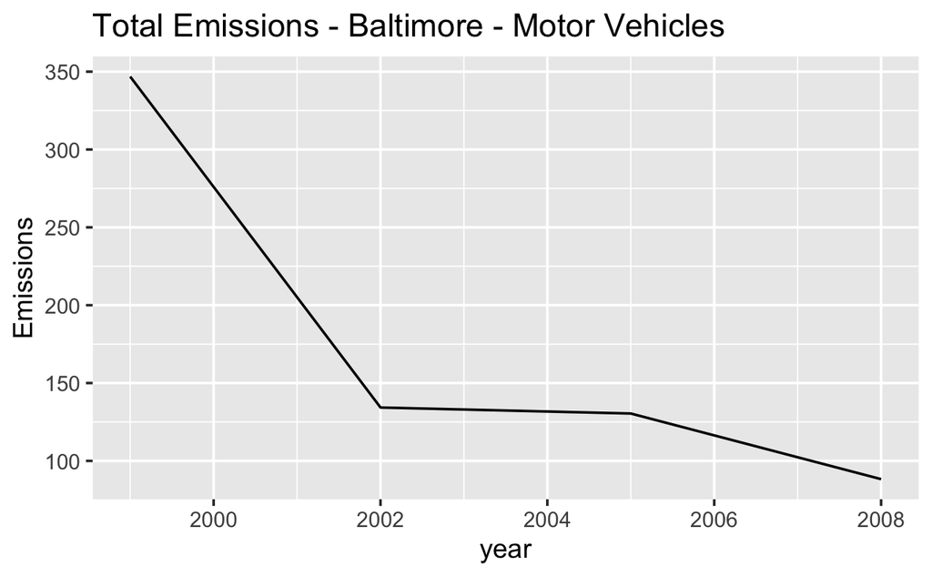

```r
# Open a png file
#png(filename = "plot5.png",
#    width = 480,
#    height = 480)

ggplot(baltimore_tot5, aes(year, Emissions)) +
    geom_line()  +
    labs(title ="Total Emissions - Baltimore - Motor Vehicles")
```

```r
# Close the png file
# dev.off()
```

### Question 6

Compare emissions from motor vehicle sources in Baltimore City with emissions from motor vehicle sources in Los Angeles County, California (fips == “06037”). Which city has seen greater changes over time in motor vehicle emissions?

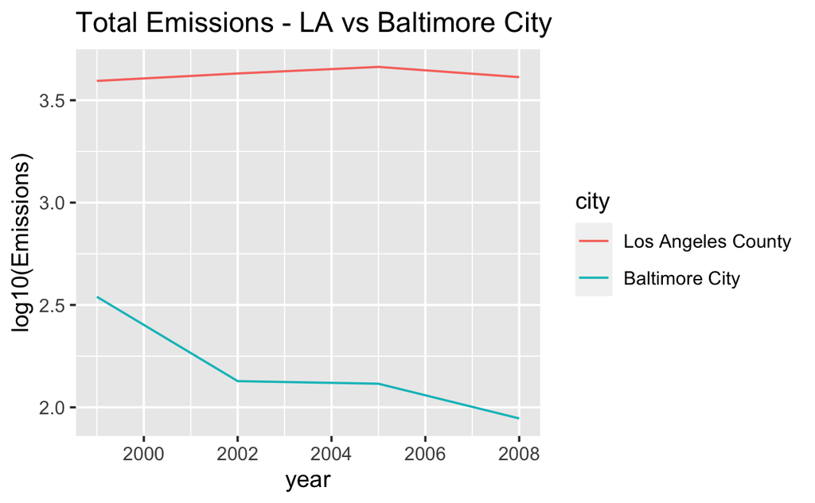

```r
nei_sample <-
    nei%>%
    filter(SCC %in% vehicle_scc) %>%
    filter(fips  %in% c("06037", "24510")) %>%
    mutate(year = year,
           city = recode_factor(fips, '06037' = "Los Angeles County",
                                '24510' = "Baltimore City")) %>%
    group_by(year, city) %>%
    summarise(Emissions = sum(Emissions),
              .groups = "drop")


ggplot(nei_sample, aes(year, log10(Emissions), color = city)) +
    geom_line()  +
    labs(title ="Total Emissions - LA vs Baltimore City")
```

```r
# take a subset of nei, Baltimore city
LA <- subset(nei, fips =="06037")
LA_vehicle <- LA[LA$SCC %in% vehicle_scc, ]
```

```r
LA %>%
    select(year, Emissions) %>%
    group_by(year) %>%
    summarise(avg_emis = mean(Emissions, na.rm=T))
```

| year | avg_emis |
| --- | --- |
| 1999 | 116.881370 |
| 2002 | 32.808752 |
| 2005 | 26.924625 |
| 2008 | 4.436764 |

```r
baltimore %>%
    select(year, Emissions) %>%
    group_by(year) %>%
    summarise(avg_emis = mean(Emissions, na.rm=T))
```

| year | avg_emis |
| --- | --- |
| 1999 | 10.231813 |
| 2002 | 4.586758 |
| 2005 | 5.703605 |
| 2008 | 2.664208 |